# POL 200 01 Political Analysis

Published

Instructor and course information

| **Instructor:** | Daniel Bowen |
| --- | --- |
| **Department:** | Political Science |
| **Units/Credits:** | 1 unit |
| **Location:** | SSB 021 (Mondays and Thursdays) and SSB 223 (Wed) |
| **Semester:** | Spring 2026 |
| **Class Time:** | Mondays and Thursdays 9:30am-10:50pm |
|  | Wednesdays 10:00 - 10:50am |
| **Open Office Hours:** | Mondays 2:00-4:45pm; |
|  | Thursdays 12:30 - 2:30pm |
|  | or by appointment |
| **Office Hours Location:** | SSB 219b or over Google Meet |
| **Email:** | bowend@tcnj.edu[^1] |
| **Google Chat:** | Main course space: [POL200.S26](https://chat.google.com/room/AAQANSDhahM?cls=7) |
| **Google Drive:** | Shared course resource folder: [pol200_s26](https://drive.google.com/drive/folders/1oMthoRGpcodcGv7s6BjOk7XIFYMIN-3U?usp=drive_link) |
| **Quiz Request Form:** | [Link to request a quiz](https://docs.google.com/forms/d/e/1FAIpQLSd2Wwh0B345i6CM0wiMQUZJZe2lNiAZyq-uM788iyoZ89F7Xg/viewform?usp=header) |

## Calendar

[Click here for the course calendar.](https://calendar.google.com/calendar/u/1?cid=Y19mYTE4YjBiZTUwYjFjZmQ0NDQwYjEwMDY2M2Q3ZGFjZmMwOGY3ZWFjNTEwYzM2N2I4ZWIxNjdhZWQ1MDYxNTc3QGdyb3VwLmNhbGVuZGFyLmdvb2dsZS5jb20)

## Office Hours Scheduler

[Click here to sign up for office hours.](https://calendar.google.com/calendar/appointments/schedules/AcZssZ2IhjNqsETKi7x5UlyM3jDcvi__n_-narHkiYopxnj7WTJjedGgSOPOOL6ltM2WbPC-9OLsd3K-?gv=true)

## Course Description and Purpose

The course familiarizes students with the basic statistical, conceptual, and technical skills needed for research in political science. Topics include research design, statistical inference, hypothesis testing, and practical experience examining and analyzing quantitative data. This course provides students hands-on training with R, a commonly used statistical software package. Should normally be completed by the end of the sophomore year prior to taking POL 390 for students majoring in political science.

Quantitative research methods are some of the most powerful tools available to understand and influence contemporary politics. The purpose of this course is to familiarize undergraduate students with common quantitative methods frequently used in the field of political science and other social sciences like economics, sociology, psychology, and criminology. In the process, this course will train students to think objectively and critically about political issues. A large portion of the course will concern basic statistics used in the social sciences and hands-on training with R, a statistical software package commonly used in political research. By the end of the class, students should be equipped with the basic statistical, conceptual, and technical skills necessary to effectively complete a quantitative research project and to act efficaciously as scholars and citizens.

POL 200 is one of Political Science’s core courses. All political science majors **must receive a C grade or better** in the course to remain in the major. For more information, please see the program bulletin for [Political Science](https://polisci.tcnj.edu/academic-advising/undergraduate-bulletin/). Students who do not meet the minimum grade threshold after a second attempt at the course will need to apply for Department approval to retake the course and stay in the major, per the Department’s course repeat policy.

## Learning Outcomes

The course meets the following learning outcomes for the Department of Political Science. Students will:

- LO3. Critical Thinking: In discussions and assigned papers students will show advanced skills in critical thinking so that they may understand complex relationships and concepts, identify underlying assumptions, and dissect a scholarly text;
- LO4. Original research: Students will conduct original research projects with data collection and methods of analysis characteristic of political science;
- LO6. Civic life: Students will graduate prepared for professional life and civic participation in a diverse society.

The course also advances the following learning goals defined by School of Humanities and Social Sciences and [Middle States Commission on Higher Education](https://www.msche.org/), TCNJ’s accrediting body:

- LO3. Scientific and Quantitative Reasoning;
- LO5. Critical Analysis and Reasoning;
- LO6. Information Literacy;
- LO11. Preparation to Participate in Civic Life;
- LO14. Understand Key Political Processes and Institutions at All Levels.

This class meets the “fourth hour” requirement in multiple ways. The course will utilize the “fourth hour” period on Wednesdays at 10am frequently for assessments. On occasion, students will be expected to finish computer labs on their own time, following materials that I prepare.

The course will use the Canvas dropbox to share and collect student work and the Canvas gradebook to provide timely information about student performance in the course. This syllabus is also posted (and updated with any changes/corrections) on the Canvas LMS.

## Course *Required* Materials

One book is required for this class and available for purchase at the bookstore or through online sellers. I strongly recommend purchasing the book. It isn’t particularly expensive, and you can keep it as a reference for your work in later years.

- Paul Kellstedt and Guy Whitten. 2018. Third Edition. Cambridge University Press.

In addition to these books, we will occasionally be reading journal articles. These are available for free from the library’s electronic resources. All required readings are listed in the References section at the end of the syllabus.

Throughout the class, we will be using the R statistical computing environment. R has several advantages over its competitor programs. As open source software, R is free, saving individuals and institutions hundreds (or even thousands) of dollars per user in licensing fees. It also has a robust group of active programmers, providing users with cutting-edge statistical routines not always available in other platforms. R also has superb graphing functionality for data visualization. Finally, R is the program (and language) of choice, along with Python, among data scientists across fields of study. R is free to download and install on your own computers (Windows, Linux, or MacOS). We will be using the R Studio GUI to interact with R. R and R Studio are also available in campus computer labs and the Virtual App.

## Course Work and Grading

### Quizzes

There will be five quizzes in the course which serve as the primary assessments for the course. *Quizzes will be on paper, in-person, and closed-book*. Here are the important details:

- Students will have 30 minutes to complete a quiz.
- Quizzes must be completed during the Wednesday morning “fourth hour” sessions (10:00am - 10:50am), and only one quiz can be attempted per Wednesday quiz session.[^2]
- Each quiz assesses student knowledge on one of five sections of the course: Research design, describing and comparing, statistical inference and probability, hypothesis testing, and regression modeling.
- Students will earn points when they display competency over the subject matter of the quiz. Each quiz will have a 20-point scale; students must earn at least 16 of 20 points to pass the quiz.
- Students can retake quizzes; indeed, there are no absolute limits to the number of attempts the student makes to pass a quiz. Students should expect at least some quiz questions will change when retaking the quiz.
- A passed quiz is worth 2 points toward the student’s final grade. If a student does not pass a quiz after three good-faith attempts, they will receive a grade of 1 point.
- Students are not allowed to attempt a quiz until they have submitted a good-faith attempt at the problem set for that section of the course.
- Students can take quizzes during the scheduled Wednesday quiz periods when they feel they are ready to attempt the quiz. Any quizzes can be attempted on any quiz period, again assuming the student has submitted their problem set for that section of the course.
- In order to attempt a quiz, students **must** complete [this Google form](https://docs.google.com/forms/d/e/1FAIpQLSd2Wwh0B345i6CM0wiMQUZJZe2lNiAZyq-uM788iyoZ89F7Xg/viewform?usp=header) requesting the quiz be prepared, no later than 11:59pm on the Tuesday before the Wednesday quiz period. The form is how I will know how many and which quizzes to bring to the session.
- Be careful, there are a limited number of quiz periods! I am planning to hold quiz sessions on the following 12 days:
  - 02/18
  - 02/25
  - 03/04
  - 03/11
  - 03/25
  - 04/01
  - 04/08
  - 04/15
  - 04/22
  - 04/29
  - 05/06
  - 05/07
- **There are no exceptions to this policy.** I will not hold make-up quiz dates or host quiz sessions on alternative days. Please plan ahead. If you run out of quiz days such that you do not pass a particular quiz or cannot take a quiz, then you will receive a 0 on any quizzes not passed.

### Research Project

Throughout the semester, we will be building the skills needed to complete an independent research project. You will select the topic, identify a research question, develop a theory informed by academic literature and at least one testable hypothesis derived from the theory, collect and clean appropriate data to test your hypothesis, and conduct your analysis based on the quantitative tools we will learn throughout the semester. Your research project will be presented using [this Quarto template](https://drive.google.com/file/d/1Xoj4X2wkgmNzVJnKWnzmoRZrjMT6g8PU/view?usp=sharing) and submitted on Canvas. The final research project submission is due during the course final exam period (TBD). The research project serves as the course’s final evaluation. Please review the checklists below in the course schedule to make sure you are staying on task for a successful completion of the research project by the end of the semester.

To facilitate the completion of the research project, students must meet with me two times during the semester during office hours. The first meeting **must take place by end of the day on 03/05**. Prior to our meeting, please send, using a DM on GChat, your research question, theory, and hypothesis (proposed) for your research project. Our meeting will provide the opportunity to fix any theoretical issues with the proposed project and identify potential data sources. The second meeting **must take place by end of day on 04/09**. At this meeting, I expect the student will share with me their data sources and describe the operationalization of their independent and dependent variables. Students must come prepared with required materials for each meeting in order to receive credit for the meeting. Please schedule meetings using the office hours scheduling link available at the beginning of the syllabus.

The following tables denotes the weight of each course component toward the final grade and grade ranges used.

Grading Weights

| Required Work | Total Points |
| --- | --- |
| Problem Sets (5) | 5 (1 pt each) |
| Quizzes (5) | 10 (2 pts each) |
| Meetings with Bowen (2) | 1 (.5 pts each) |
| Project Report | 4 |

Figure 1: Grading Scale

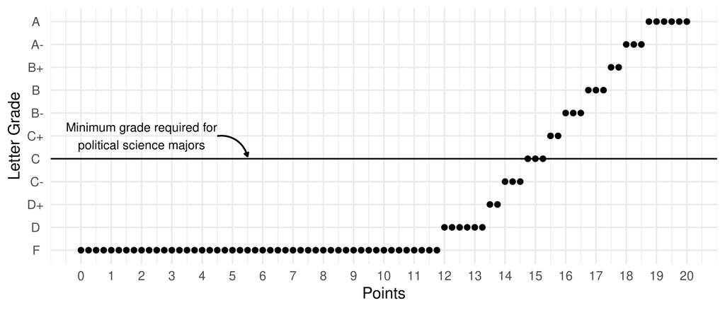

## What To Do If You Are Sick

If you’re not feeling well, do not come to class. Your grade is not based on attendance or participation. You will have access to lecture notes, labs, and announcements through regularly-updated course materials on Google Drive, GChat, and Canvas. You can get additional notes about anything you miss from a colleague. I would appreciate it if you send me a quick GChat DM to let me know that you are not feeling well and need to miss class.

## Course Policies

*AI Policy:* Most students are likely using some “AI” tools - these days it is hard not to, as technology companies integrate AI into nearly all of their services. However, AI is particularly dangerous for students because it can undermine the learning process. I want to empower **you** to be able to complete the tasks associated with the course and build your methodological and analytical toolset. We cannot do that if you substitute AI “work” for your own thinking and effort. Even more importantly, AI and large-language models (LLM) make substantial errors, and you need to know enough to know when you can and cannot trust such systems. So here are my expectations:

- Writing: do not use AI tools for writing or editing. I will not require much writing in this course, and what writing is required is technical in nature. You will need to practice it to become familiar with the conventions.
- Analysis and problem sets: Each problem set builds on material covered by a lab that we will go over in class. All of the functions that are necessary to complete the problem sets are included in these labs. **If you plan to use any functions not covered in class, you must write a paragraph explaining what every step of the new function and surrounding code does, in order to get credit.** You must do this for each additional function included in your homework, not covered in class. I do, however, think that modern AI-infused search can be helpful when you are stuck on some portion of some code that is continuously throwing errors. Feel free to use tools available to you that help you troubleshoot your errors, but do not substitute ChatGPT, Claude, or Gemini’s work for your own.

*Commitment to diversity, equity, inclusion, access, and belonging:* The TCNJ community is composed of people with diverse backgrounds, perspectives, and experiences, and the college is committed to diversity, equity, inclusion, access and belonging. The college’s Campus Diversity Statement can be viewed here: https://diversity.tcnj.edu/campus-diversity-statement/.

*Classroom environment & commitment to student success, safety, and well-being:* The TCNJ community is dedicated to the success, safety and well-being of each student. TCNJ strictly follows key policies that govern all TCNJ community members rights and responsibilities in and out of the classroom. In addition, TCNJ has established several student support offices that can provide the support and resources to help students achieve their personal and professional goals and to promote health and well-being. You can find more information about these policies and resources at the “TCNJ Student Support Resources and Classroom Policies” webpage here: https://academicaffairs.tcnj.edu/tcnj-syllabus-resources/. Students who anticipate and/or experience barriers in this course are encouraged to contact the instructor as early in the semester as possible. The Accessibility Resource Center (ARC) is available to facilitate the removal of barriers and to ensure reasonable accommodations. For more information about ARC, please visit: https://arc.tcnj.edu/.

This course will adhere to all TCNJ policies. See https://academicaffairs.tcnj.edu/tcnj-syllabus-resources/ for information on TCNJ classroom policies and student support services.

*Late policy:* Problem sets and quizzes do not have standard due dates. No make up opportunities are available for students who do not schedule and attend their instructor meetings. No late final projects will be accepted unless I grant an extension prior to the final exam period.

*Course repeat policy:* Students are allowed by College policy to retake a course once without additional approval. After a student fails a required class or doesn’t meet a required grade threshold for the second time, they must petition the department for approval to attempt the course for a third time. The full policy is online: https://polisci.tcnj.edu/forms/.

## Course Schedule

Full bibliographic entries are available in the References section. Assigned readings should be completed by the start of class.

*Part I: Research Design Principles*

1. Sessions
   - *01/27* Introduction to quantitative analysis and a scientific study of politics ([lecture](https://drive.google.com/file/d/1VPBQdrhlKO4RNgafuRFgTHEhXD7o0z8C/view?usp=sharing)). Read Kellstedt and Whitten (2018), Ch 1.
   - *01/29* Research questions, theories, and hypotheses ([lecture](https://drive.google.com/file/d/1OSi7zD1L6P9B4Faz4CaywOrS1dVsas5p/view?usp=sharing)); R and RStudio installation ([lab](https://drive.google.com/file/d/1uz357S0I2J6EDF_9XM3da0GM1-3mwUK5/view?usp=drive_link)). Read Kellstedt and Whitten (2018), Ch 2-3.
   - *02/02* Measuring theoretical concepts empirically ([lecture](https://drive.google.com/file/d/1G-YgrZgC1K3BcZGmi2jgsBrxogt4FuGE/view?usp=sharing)). Read Lee (2016). [Available here.](https://drive.google.com/file/d/1AiLcZ4OBTn5U-QkXphk986nI3GhHQ8jv/view?usp=drive_link)
   - *02/05* Introduction to data management in R ([lab](https://colab.research.google.com/github/bowendc/pol200_labs/blob/main/basic_data_management.ipynb)). Read Kellstedt and Whitten (2018), Ch 5-6.2.3 and Jefferson (2024). [Available here.](https://drive.google.com/file/d/1FTD_e2urDlDWLBFFIUp3HlyWypuUTgcX/view?usp=sharing)
   - *02/09* Experimental and observational research designs ([lecture](https://drive.google.com/file/d/1GSRKHw-IZBok2FF_QH61A-QJeHkXXPIG/view?usp=sharing)). Read Kellstedt and Whitten (2018), Ch 4.
2. Assessments
   - [Research design problem set](https://drive.google.com/file/d/1fovQSy3HbgUtbI79Hn-l4yYIGI1Kztqk/view?usp=sharing)
   - Research design quiz
3. Research project checklist
   - Brainstorm project ideas
   - Develop theoretical explanation for causal relationship
   - Consider measurement of independent and dependent variables

*Part II: Describing and Comparing*

1. Sessions
   - *02/12* Describing variables; descriptive statistics ([lecture](https://drive.google.com/file/d/1xUlv7ERb9PO6GfKYCVqS6GYziZD6xdxN/view?usp=sharing), [lab](https://colab.research.google.com/github/bowendc/pol200_labs/blob/main/describing.ipynb)). Read Kellstedt and Whitten (2018), Ch 6.2.4 - 6.6.
   - *02/16* Bivariate comparison tests ([lecture](https://drive.google.com/file/d/1vJeI1H7CkJ4ZBiqNDGi8qmN1iacoOeTw/view?usp=sharing), [lab](https://colab.research.google.com/github/bowendc/pol200_labs/blob/main/basic.comparisons.ipynb)). Read Schaffner and Roche (2016).
   - *02/23* Covariance and correlation ([lecture](https://drive.google.com/file/d/17DOg2h_gSlAbcwgOHXZnE1zoXquqS-wt/view?usp=sharing), [lab](https://colab.research.google.com/github/bowendc/pol200_labs/blob/main/cov_corr_ols.ipynb)). Read Inglehart (2003).
   - *02/26* Graphing with `ggplot`, part I ([lab](https://colab.research.google.com/github/bowendc/pol200_labs/blob/main/graphing_part1.ipynb)).
   - *03/02* Introduction to ordinary least squares regression ([lecture](https://drive.google.com/file/d/1cJaa_fdWVLb5iHzyQKYML6OfB11PZMRh/view?usp=sharing), [lab](https://colab.research.google.com/github/bowendc/pol200_labs/blob/main/cov_corr_ols.ipynb)). Read Kellstedt and Whitten (2018), Ch 9.0 - 9.3.
2. Assessments
   - [Describing and comparing problem set](https://drive.google.com/file/d/11N0DTziZlU6EvO5bLHpbMfxLEqbfWWWu/view?usp=sharing)
   - Describing and comparing quiz
3. Research project checklist
   - Select project topic
   - Finalize research question, theory, and hypothesis
   - Meet with Bowen by 03/05 to discuss RQ, theory, and hypothesis
   - Start search for available data source(s)

*Part III: Statistical Inference and Probability*

1. Class topics
   - *03/05* Probability and statistical inference core concepts ([lecture](https://drive.google.com/file/d/1uUSMAE_ohBeurE3r65O1AWuvUyrZQeqN/view?usp=sharing)); merging and joining datasets ([lab](https://colab.research.google.com/github/bowendc/pol200_labs/blob/main/merging_data.ipynb)). Read Kellstedt and Whitten (2018), Ch 7
   - *03/09* The Central Limit Theorem, the Normal, and Student’s *t* distributions ([lecture](https://drive.google.com/file/d/1_WgPpArZtUt0JUr-HeAMsABhK3kTUFlx/view?usp=sharing));
   - *03/12* The Central Limit Theorem, the Normal, and Student’s *t* distributions continued ([lecture](https://drive.google.com/file/d/1_WgPpArZtUt0JUr-HeAMsABhK3kTUFlx/view?usp=sharing))
   - *03/19* Graphing with `ggplot`, part II ([lab](https://colab.research.google.com/github/bowendc/pol200_labs/blob/main/graphing_part2.ipynb))
2. Assessments
   - [Statistical inference and probability problem set](https://drive.google.com/file/d/1yFFAg6juC-L8Qi_iVe-SlyW3f29UbfI_/view?usp=sharing)
   - Statistical inference and probability quiz
3. Research project checklist
   - Identify potential data sources
   - Start data collection and cleaning
   - Examine academic literature for relevant research

*Part V: Linear Regression Modeling*

1. Sessions
   - *04/06* Multiple regression ([lecture](https://drive.google.com/file/d/1DL6XpY2UHU5MJXAaZnNrv-Ifn1Sq5-X1/view?usp=sharing)). Read Kellstedt and Whitten (2018), Ch 9.4 - 10.10.
   - *04/13* Dummy variables, interactions and transformations ([lecture](https://drive.google.com/file/d/1G6nCTmTzUgZwbji-IGpsDhZdyr3-mNJZ/view?usp=sharing)). Read Kellstedt and Whitten (2018), Ch 11.
   - *04/16* Regression modeling and presenting regression results ([lab](https://colab.research.google.com/github/bowendc/pol200_labs/blob/main/regression_modeling.ipynb)). Read Trounstine (2016).
   - *04/20* Regression assumptions ([lecture](https://drive.google.com/file/d/1tFneuyDx0DrD-6QhvJNpG12vue6q_5Ss/view?usp=sharing))
   - *04/23* Regression assumptrions (continued)
   - *04/27* Prediction and marginal effects ([lecture](https://drive.google.com/file/d/1mjOCLjZvLwCMWGwGYTUTtySQNHTAWSBZ/view?usp=sharing) and [lab](https://colab.research.google.com/github/bowendc/pol200_labs/blob/main/prediction.ipynb))
   - *04/30* Regression recap and research project workshop
   - *05/04* Limitations of regression
   - *05/07* Last quiz day
2. Assessments
   - [Regression modeling, regression tables, and prediction problem set](https://drive.google.com/file/d/1FuJ1hOkoZLle76_Sg1LzsVl_eB-kE0W0/view?usp=sharing)
   - Linear regression modeling quiz
3. Research project checklist
   - Finalize dataset
   - Conduct analysis
   - Work on project report using Quarto template

Final project due during scheduled final exam period (Thursday, May 14th, at noon).

## Disclaimer

The instructor reserves the right to make changes to this syllabus.

## References

Inglehart, Ronald. 2003. “How Solid Is Mass Support for Democracy - and How Can We Measure It?” *Public Opinion Quarterly* 36 (1): 51–57.

Jefferson, Hakeem. 2024. “The Curious Case of Black “Conservatives”: Assessing the Validity of the Liberal-Conservative Scale Among Black Americans.” *Public Opinion Quarterly* 88 (3): 909–32. https://doi.org/10.1093/poq/nfae037.

Kellstedt, Paul M, and Guy D Whitten. 2018. *The Fundamentals of Political Science Research*. Third. Cambridge University Press.

Lee, Frances. 2016. *Insecure Majorities: Congress and the Perpetual Campaign*. Chicago London: The University of Chicago Press.

Schaffner, Brian F, and Cameron Roche. 2016. “Misinformation and Motivated Reasoning: Responses to Economic News in a Politicized Environment.” *Public Opinion Quarterly* 81 (1): 86110.

Trounstine, Jessica. 2016. “Segregation and Inequality in Public Goods.” *American Journal of Political Science* 60 (3): 709–25. https://doi.org/10.1111/ajps.12227.

## Footnotes

[^1]: I will do my best to respond to any emails within 36 hours during the work week or 48 hours over the weekend/holidays
[^2]: We will hold one quiz day on Thursday, May 7th as well.